# Analise_Telefone_publicos

```python
import pandas as pd
```

**Introdução**

Orelhão, oficialmente Telefone de Uso Público (TUP) é o nome dado ao protetor para telefones públicos projetado pela arquiteta e designer brasileira, nascida na China, Chu Ming Silveira. Lançado em meados de 4 de abril de 1972, inicialmente nas cidades do Rio de Janeiro e São Paulo.Hoje, encontram-se orelhões instalados por todo o Brasil, em países da América Latina, como Peru, Colômbia e Paraguai, em países africanos como Angola e Moçambique, na China e em outras partes do mundo.

Nos anos 1920, a instalação dos primeiros telefones semi públicos, no Brasil. Esses aparelhos acompanhavam um compartimento de moedas eram encontrados em estabelecimentos comerciais, onde os donos tinham contratos com compania telefonica.

Os telefones realmente públicos só chegaram às calçadas brasileiras em meados de 1971, quando mais de 93 milhões de pessoas já habitavam o vasto território nacional e nem se sonhava em carregar um telefone no bolso ou bolsa. A telefonia móvel era algo apenas do imaginário e o telefone celular só seria lançado em 1973, acessível a bem poucos.

Dos quase 100 milhões de habitantes do Brasil, 52 milhões viviam em áreas urbanas, segundo dados do IBGE. O resultado disso é que, em muitos locais, ouvir e ser ouvido a partir de um telefone público, instalado no meio da rua, representava um verdadeiro desafio. Como solução para o problema, a CTB desenvolveu cabines circulares de fibra de vidro e acrílico resistente a chuva e sol. e, para testar a novidade, instalou 13 delas na cidade de São Paulo. O resultado não agradou à companhia que detectou utilização inadequada do equipamento, alto índice de vandalismo e concluiu ainda, que a espaçosa cabine, além de abafada, acabava por disputar com os transeuntes, o exíguo espaço das calçadas.

Anos depois a moeda foi subtituida por cartões com valores definidos que iam debitando ao decorrer das ligaççoes.

Aqui uma ilustração Sobre o orelhão e o cartão que as pessoas uasam para realizarem as comonicações:

[figure not shown]

Com tudo nos dias de hoje, com a pessoas tendo telefones celulares conectados a internet, mensageiros instantâneos, o uso desses TUP's foram caíndo em desuso.

**Propósito da Análise de dados**

Essa análise tem como objetivo de ver como anda esse tipo de tecnologia nos dias atuais. Se temos TUP's ativos ou não e a quantidade de TUP em mauntenções

## Perguntas a serem resposndidas

- TUP'S status por estado;
- TUP's 24hotas por estado;
- TUP's Adaptados (Audio) por estado;
- TUP's Adaptados (cadeirante) por estado;
- Operadoras por estados;
- TUP's por Operadoras;

# Limpesa dos dados - Data Cleaning

**Lendo a base de dados**

```python
linhas = pd.read_csv('./TUP.csv')
```

```python
linhas.head()
```

|  | FID | est_geom | id_tup | idttup | concessionaria | status | numero | dtativacao | dataultimacomunicacao | siglauf | ... | bairro | logradouro | complemento | cep | deficientecadeirante | deficienteaudio | vintequatrohoras | latitude | longitude | metadado |
| --- | --- | --- | --- | --- | --- | --- | --- | --- | --- | --- | --- | --- | --- | --- | --- | --- | --- | --- | --- | --- | --- |
| 0 | TUP.fid-50a24ac0_16c0a514e41_286d | POINT (-51.081388 0.03111) | 1387536999 | 93281 | OI | DISPONIVEL | (96) 32441623 | 03/09/2001 | 15/07/2019 11h07 | AP | ... | NOVA ESPERANCA | RUA SECUNDINO CAMPOS | 0 | 68901750.0 | NAO | NAO | NAO | 0.031110 | -51.081388 | <a href="http://sistemas.anatel.gov.br/geonetw... |
| 1 | TUP.fid-50a24ac0_16c0a514e41_286e | POINT (-51.055555 0.075554) | 1387537000 | 93282 | OI | DISPONIVEL | (96) 32511964 | 22/12/1993 | 18/07/2019 04h07 | AP | ... | SAO LAZARO | RUA ADILSON JOSE PINTO PEREIRA | 0 | 68908571.0 | NAO | NAO | NAO | 0.075554 | -51.055555 | <a href="http://sistemas.anatel.gov.br/geonetw... |
| 2 | TUP.fid-50a24ac0_16c0a514e41_286f | POINT (-51.130277 0.039166) | 1387537001 | 93283 | OI | DISPONIVEL | (96) 32271182 | 24/03/2001 | 18/07/2019 12h07 | AP | ... | MARABAIXO | RUA QUARTA | 0 | 68909870.0 | NAO | NAO | SIM | 0.039166 | -51.130277 | <a href="http://sistemas.anatel.gov.br/geonetw... |
| 3 | TUP.fid-50a24ac0_16c0a514e41_2870 | POINT (-51.072221 0.02611) | 1387537002 | 93284 | OI | DISPONIVEL | (96) 32421781 | 18/01/2002 | 17/07/2019 10h07 | AP | ... | TREM | AV DIOGENES SILVA | 0 | 68901090.0 | NAO | NAO | NAO | 0.026110 | -51.072221 | <a href="http://sistemas.anatel.gov.br/geonetw... |
| 4 | TUP.fid-50a24ac0_16c0a514e41_2871 | POINT (-51.068888 0.006666) | 1387537003 | 93285 | OI | DISPONIVEL | (96) 32411303 | 06/11/1997 | 18/07/2019 08h07 | AP | ... | JARDIM EQUATORIAL | AV JOAO DE CASTRO SUSSUARANA | 0 | 68903006.0 | NAO | NAO | NAO | 0.006666 | -51.068888 | <a href="http://sistemas.anatel.gov.br/geonetw... |

5 rows × 22 columns

Iremos utilizar uma biblioteca chamada pandas profiling é como se fosse usar o comando describe() que te retonar informações estatísticas. Porém o pandas profilling te retornar informações mais completas. E é muito bem vindo nessa fazerde Limpesa de doados. Com ela teremos a vissão de como encontra-se nosso DataFrame e poderemos tomar varias decisões de normalização de dados só de ver o resultado do profiling

```python
# Nota: Essa lib costuma da erro de import. Logo terá que er instalada em sua máquina. :)
import pandas_profiling as PR
```

```python
linhas.isnull().sum()
```

```
FID                          0
est_geom                     0
id_tup                       0
idttup                       0
concessionaria               0
status                       0
numero                       0
dtativacao                   0
dataultimacomunicacao        0
siglauf                      0
nomemunicipio                0
localidade                   0
bairro                    1502
logradouro                   1
complemento              47099
cep                          2
deficientecadeirante         0
deficienteaudio              0
vintequatrohoras             0
latitude                     0
longitude                    0
metadado                     0
dtype: int64
```

```python
PR.ProfileReport(linhas)
```

[interactive chart not shown]

Viu so como o pandas profiling é util? Ele te da um relatório de como encontra-se seu data set. Iemos então normalizar os dados faltantes. Nota basicamente as unicas colnas a serem normalizadas seriam o cep e bairro . Devido o DataFrame se sobre localidaddes de TUP's , erma para exisitir esses valores nessas colunas. No Complemento onde encontra-se mais valores faltantes. Se for pensar não é um dado obrigatório . Então é normal termos essa coluna com esse alto valor faltante. Porém iremos limpar tudo.

```python
linhas.dropna(axis=1 ,inplace=True)
```

```python
linhas.isnull().sum()
```

Usamos e motedo dropna() para deletar todos todas as colunas com dados faltantes passado o exis= 1. Ou seja o 1 = Coluna e 0 são indexs. Logo depois pegamos o DataFrame e usamos o metodo isnull() que identifica os valores faltante e somamos ele com o metodo sum().

### Bom sobre valores escrepantes . As colunas númericas que temos, nada mias é que colunas com ids e latitude e longitude. Logo não será nescessário analisar esses valores escrepantes.

## Relembrando as perguntas a serem resposndidas

- TUP'S status por estado;
- TUP's 24hotas por estado;
- TUP's Adaptados (Audio) por estado;
- TUP's Adaptados (cadeirante) por estado;
- Operadoras por estados;
- TUP's por Operadoras;

```python
import matplotlib.pyplot as plt
```

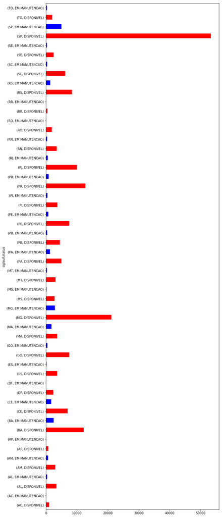

```python
# TUP'S status por estado;
ax= linhas.groupby("siglauf")['status'].value_counts().plot(kind="barh",color=["red","blue"],figsize=(10,30))
plt.show()
```

2ª MG DISPONIVEL 21077 EM MANUTENCAO 2854

4ª BA DISPONIVEL 12239 EM MANUTENCAO 2449

Citei o quarto lugar devido os valores serem muito próximos ao terceiro. Caso queria visualizar esses valores sem fora do gráfico, basta executaro comando : linhas.groupby("siglauf")['status'].value_counts()

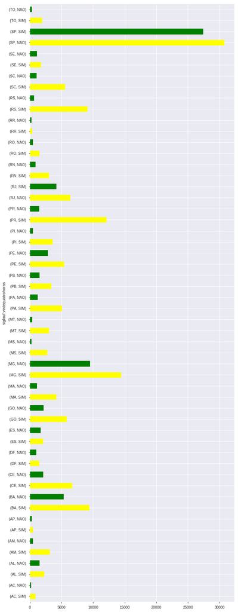

```python
#TUP's 24hotas por estado;
ax= linhas.groupby("siglauf")['vintequatrohoras'].value_counts().plot(kind="barh",color=["yellow","green"],figsize=(10,30))
plt.show()
```

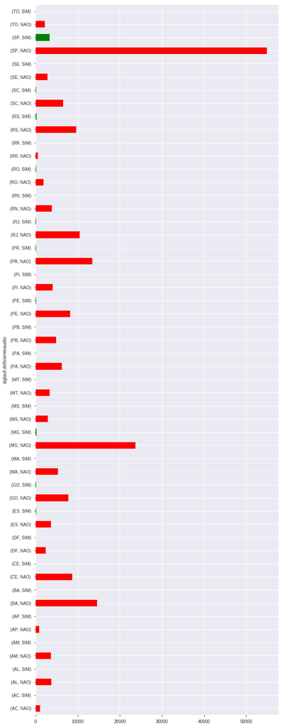

```python
# TUP's Adaptados (Audio) por estado
ax= linhas.groupby("siglauf")['deficienteaudio'].value_counts().plot(kind="barh",color=["red","green"],figsize=(10,30))
plt.show()
```

Neste gráfico podemos ver claramente que os TUP's não são adaptados para deficientes auditivos. São bem poucos que apresentam essa adaptabilidade.

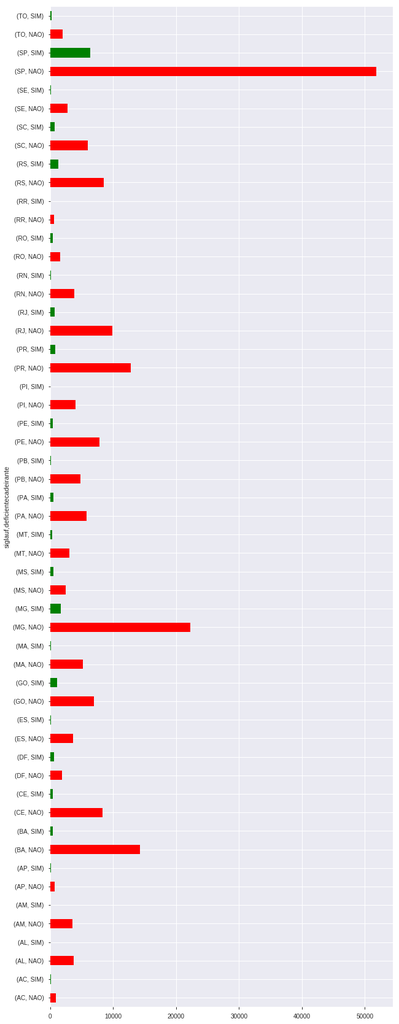

```python
# TUP's Adaptados (Cadeirante) por estado
ax= linhas.groupby("siglauf")['deficientecadeirante'].value_counts().plot(kind="barh",color=["red","green"],figsize=(10,30))
plt.show()
```

Esse grafico é bastante parecido com o anterios de auditivo temos muitos TUP's não adaptados.

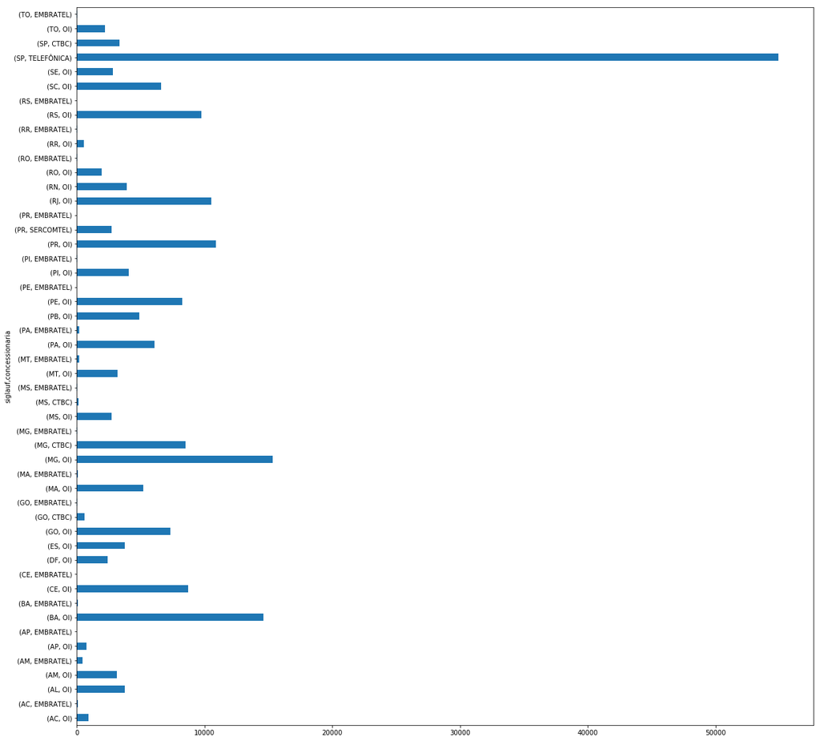

```python
#Operadoras por estados;
linhas.groupby("siglauf")["concessionaria"].value_counts().plot(kind="barh",figsize=(20,20))
```

Nesse gráfico é mostrado as operador por estado com destaque para SP , usando a telefônica.

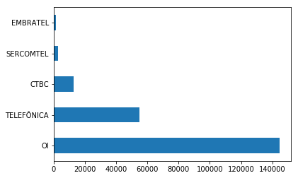

```python
# Tups por Operadoras
linhas['concessionaria'].value_counts().plot(kind="barh")
```

Esse gráfico mostra a quantidade TUP's por operadoras. Uma coisa interessante que no gráfico anterior a consentração de TUPS's por parte da OI é bem difundida . E a Telefônica toda concentrada em SP. Sendo que no gráfico acima, sua concentração é menor que da OI .